# HIV virulence evolution in structured epidemic models

22:25 03 February 2016

## Intro to virulence evolution

## Tradeoff theory

- assume that virulence evolution is mediated by parasite-level tradeoff between transmission and "virulence" (clearance/mortality rate)
- need a *saturating* relationship: \(\frac{d^2 \, \textrm{transmission}}{d\,\textrm{clearance}^2}<0\)
- mediated through pathogen replication rate (?)
- simple form assumes no within-host competition (single clone per host)
- alternatives: short-sighted evolution, within-host competition, effects of genetic drift … (Levin & Bull, 1994,Ebert & Bull (2003))

## Eco-evolutionary dynamics

- feedback between ecological and evolutionary processes
- typical emphasis on *short-term* dynamics (cf. adaptive dynamics)
- eco-evo-epi: *transient virulence* (Bolker et al., 2010)
- balance between \(r\)-selection (epidemic phase) and \({\cal R}_0\)-selection (endemic phase)
- transient peak observed in phage systems (Berngruber et al., 2013)

## Modeling virulence evolution in HIV

## Shirreff et al. (2011) : evolutionary/within-host

- generally based on Rakai estimates
- Normally distributed mutation
- Normally distributed phenotypic variation
- different infectivity for early, mid, late HIV stages
- Hill functions (\(x^d/(a+bx^d)\)) for infectivity, progression through mid stage
- Weibull time in mid stage

## Shirreff et al. (2011) : epidemiological

- **very simple**
- implicit partnership-formation model \[ \textrm{foi} = \frac{\beta c}{\beta + c + 1/d} \]
- derived from \({\cal R}_0\) for an instantaneous-partnership-formation model, e.g. T. D. Hollingsworth et al. (2008), Diekmann & Heesterbeek (2000)
- (Herbeck et al. (2014) is worse [I think])

## Epidemiological models for HIV (Champredon et al., 2013)

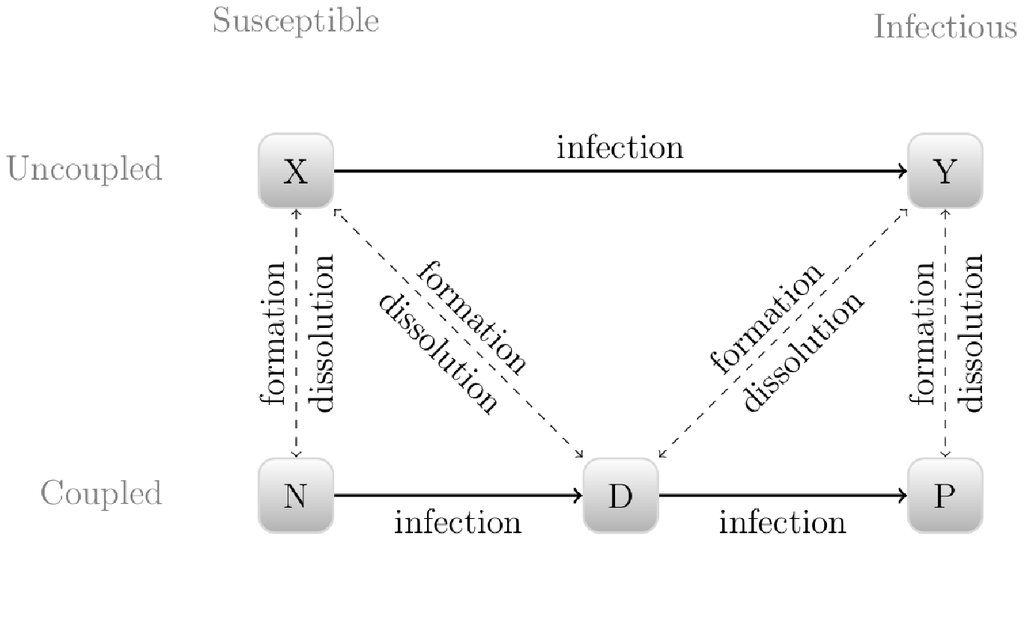

## Model modifications

- Champredon et al. (2013) track \(\{X,Y,N,D,P\}\) (\(\{S,I,SS,SI,II\}\)) \(\times\) infected strain
- we need \(\{S,SS,I(\alpha),SI(\alpha),II(\alpha,\alpha')\}\)
- simplifications:
  - single-stage, exponential infectious period  
    (\(\beta =\) time-weighted average of \(\beta_1\), \(\beta_2(\alpha)\), \(\beta_3\))
  - no phenotypic variation

## Model variations

- 4 models:
  - extra-pair contact (yes/no)
  - instantaneous partnership formation (yes/no)
- implicit (Shirreff/Hollingsworth) model

## Latin hypercube sampling

- sample evenly, randomly across (potentially many) uncertain parameters
- following Champredon et al. (2013), earlier Blower et al. (1991)

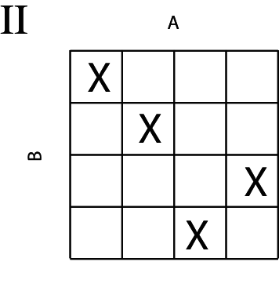

[User:Saittam, Wikipedia](https://commons.wikimedia.org/wiki/File:LHSsampling.png#/media/File:LHSsampling.png)

## Details

- \(r\) varies widely across parameters/model sets
  - *scale* parameters to \(r=0.04\) (partnership formation, dissolution, *and* transmission probability)
  - scale both uncoupled and extra-coupled rates relative to within-coupled rate
- *response variables*
  - equilibrium virulence
  - peak virulence time (years)
  - peak virulence
  - relative peak virulence (peak/eq)

## Results

## Epidemic trajectories

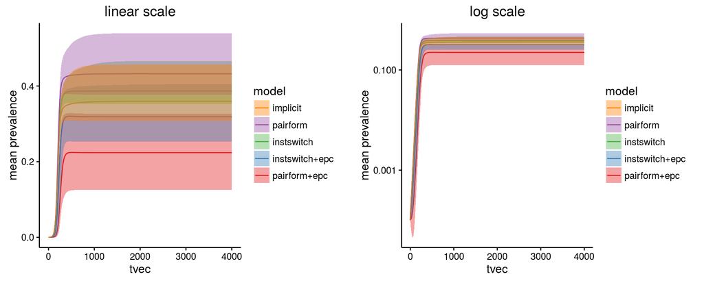

## Virulence trajectories

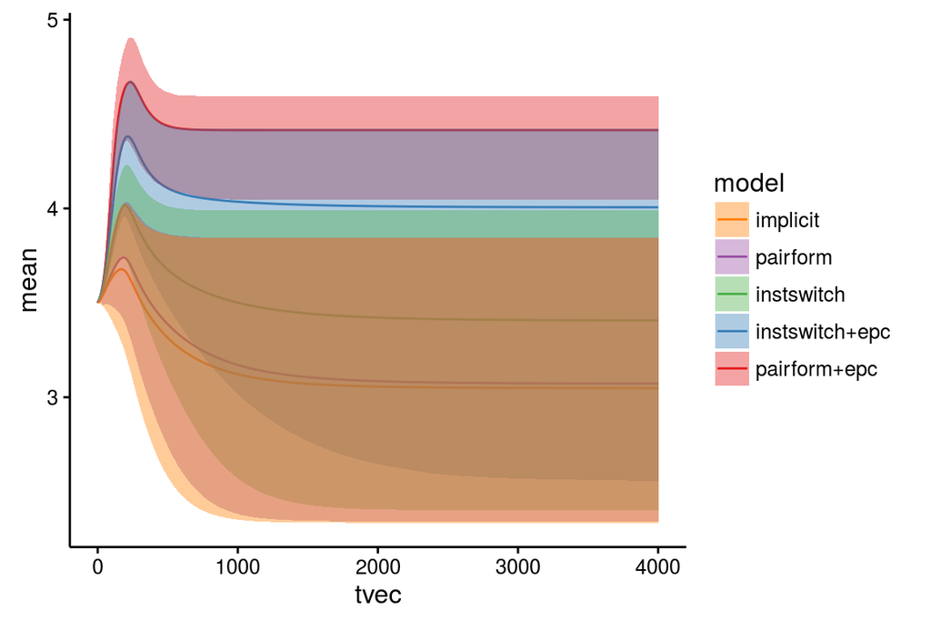

## Univariate distributions

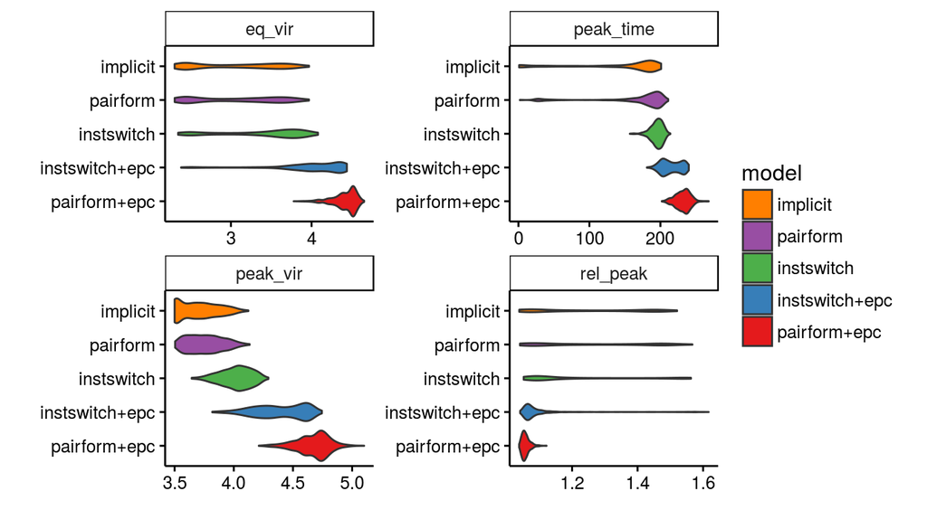

## Pairs plots

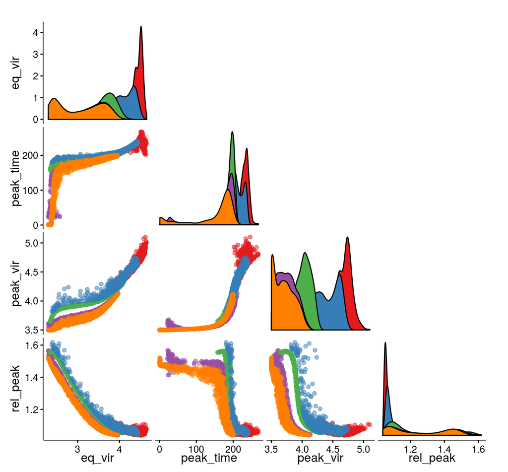

## Sensitivity

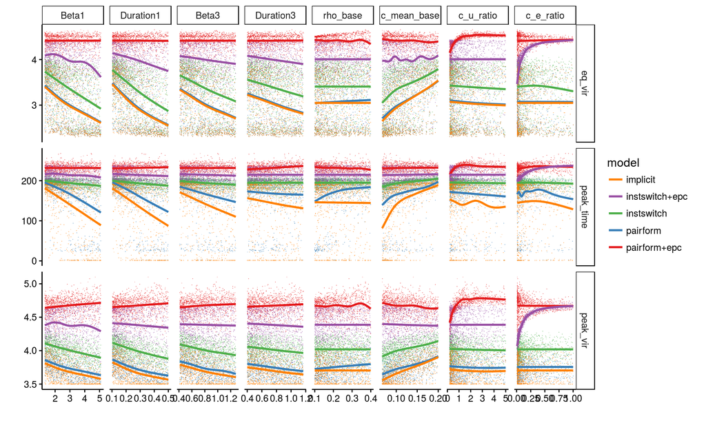

## Conclusions/questions: big picture

- how do we decide what to pick on?
- how does scaling \(r\) help/hurt?

## References

Berngruber, T. W., Froissart, R., Choisy, M., & Gandon, S. (2013). Evolution of virulence in emerging epidemics. *PLoS Pathog*, *9*(3), e1003209. http://doi.org/10.1371/journal.ppat.1003209

Blower, S. M., Hartel, D., Dowlatabadi, H., Anderson, R. M., & May, R. M. (1991). Drugs, Sex and HIV: A Mathematical Model for New York City. *Philosophical Transactions of the Royal Society of London B: Biological Sciences*, *331*(1260), 171–187. http://doi.org/10.1098/rstb.1991.0006

Bolker, B. M., Nanda, A., & Shah, D. (2010). Transient virulence of emerging pathogens. *J. R. Soc. Interface*, *7*(46), 811–822.

Champredon, D., Bellan, S., & Dushoff, J. (2013). HIV sexual transmission is predominantly driven by single individuals rather than discordant couples: A model-based approach. *PLoS ONE*, *8*(12), e82906. http://doi.org/10.1371%2Fjournal.pone.0082906

Diekmann, O., & Heesterbeek, J. A. P. (2000). *Mathematical Epidemiology of Infectious Diseases: Model Building, Analysis and Interpretation*. Wiley.

Ebert, D., & Bull, J. J. (2003). Challenging the trade-off model for the evolution of virulence: Is virulence management feasible? *Trends Microbiol*, *11*(1), 15–20.

Fraser, C., Hollingsworth, T. D., Chapman, R., Wolf, F. de, & Hanage, W. P. (2007). Variation in HIV-1 set-point viral load: Epidemiological analysis and an evolutionary hypothesis. *PNAS*, *104*, 17441–17446.

Herbeck, J. T., Mittler, J. E., Gottlieb, G. S., & Mullins, J. I. (2014). An HIV epidemic model based on viral load dynamics: Value in assessing empirical trends in HIV virulence and community viral load. *PLoS Comput Biol*, *10*(6), e1003673.

Hollingsworth, T. D., Anderson, R. M., & Fraser, C. (2008). HIV-1 Transmission, by Stage of Infection. *Journal of Infectious Diseases*, *198*(5), 687–693. http://doi.org/10.1086/590501

Levin, B. R., & Bull, J. J. (1994). Short-sighted evolution and the virulence of pathogenic microorganisms. *Trends Microbiol*, *2*, 76–81.

Shirreff, G., Pellis, L., Laeyendecker, O., & Fraser, C. (2011). Transmission selects for HIV-1 strains of intermediate virulence: A modelling approach. *PLoS Computational Biology*, *7*(10), e1002185. http://doi.org/10.1371/journal.pcbi.1002185